# Wind Power Ramp Events: Early Signals and Operational Risk

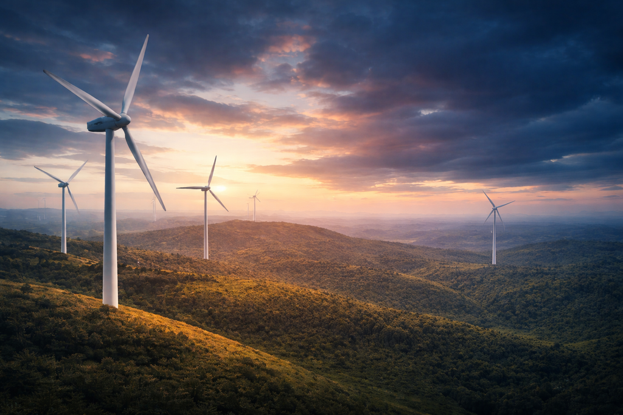

## Our Audience

This project is designed for a mixed audience that includes technical practitioners, data scientists, and energy professionals, as well as non-technical stakeholders such as planners, analysts, and decision-makers interested in renewable energy operations. While the analysis is technically grounded, the presentation prioritizes clarity, interpretability, and visual evidence to ensure accessibility across disciplines.

## Introduction

Wind power plays a critical role in the transition toward a low-carbon energy system, but its inherent variability presents ongoing operational challenges. One of the most disruptive of these challenges is the occurrence of wind power ramp events—large and sudden changes in power output over short periods of time. These events can strain grid operations, increase balancing costs, and reduce system reliability if not anticipated in advance.

This project explores wind power ramp behavior from a data-driven perspective, focusing on how observable patterns in power output and weather conditions can support earlier awareness of ramp risk. Rather than emphasizing complex forecasting models, the analysis highlights structural insights and practical signals that are relevant for real-world operations.

## Motivation

Traditional approaches to monitoring wind power variability often rely on static thresholds or single indicators, such as wind speed. However, these methods frequently fail to capture the onset of ramp events, leaving operators with limited reaction time. As wind penetration increases, the cost of reactive responses grows, creating a clear need for more informative and interpretable approaches.

The motivation behind this project is to move beyond rule-based monitoring and toward a pattern-oriented understanding of ramp behavior, enabling earlier detection of instability and more proactive operational planning.

## Key Topics

This project centers on understanding wind power ramp events as a manifestation of short-term variability in renewable energy systems. It examines how rapid changes in power output emerge under seemingly similar operating conditions and why traditional single-variable indicators, such as wind speed, are often insufficient. A central theme is the role of short-term volatility as an early warning signal, enabling earlier recognition of instability before large power swings occur. The analysis also explores structural patterns in the data using unsupervised learning techniques to assess whether ramp events form distinct operating regimes or arise as transition states at the boundaries of normal conditions. Throughout the project, emphasis is placed on interpretable, data-driven methods that translate complex patterns into insights relevant for operational decision support.

## Main Questions

The analysis is guided by three core questions:

1. **Why do simple wind-speed indicators fail to explain ramp events?** This question examines the limitations of single-variable monitoring and motivates the need for multi-dimensional analysis.
2. **Which observable signals provide early warning of ramp risk?** This question focuses on identifying dynamic features—particularly short-term variability—that distinguish ramp periods from stable operation.
3. **Do ramp events represent distinct regimes or transition states?** This question explores whether ramp events form separate operating modes or emerge gradually at the boundaries of normal conditions.

These questions connect the data analysis directly to operational interpretation.

## Call to Action

This project invites readers to engage with the analysis, explore the visual evidence, and consider how the findings can inform real-world wind power operations. Technical readers are encouraged to examine the methods and modeling choices in detail, while practitioners and decision-makers can focus on the key insights and operational implications.

For those interested in renewable energy analytics, early-warning systems, or applied data science, this work provides a foundation for further research, collaboration, and practical implementation.